# BIOS 667 - Lecture 5: Modeling the Mean - Response Profiles (Ch. 5)

Fitzmaurice, Laird & Ware (2011) - Applied Longitudinal Data Analysis

Naim Rashid

## Lecture Objectives

By the end of this lecture, you will be able to:

- Define response profiles and explain when they are appropriate for longitudinal data
- Formulate and test the three key hypotheses: parallelism, flatness, and same level
- Set up the general linear model (LM) framework for response profile analysis
- Choose among four baseline handling strategies based on study design
- Implement response profile analysis in R using `nlme::gls()` with unstructured covariance

## Roadmap

| Section | Topic |
| --- | --- |
| 1 | Motivation and concept of response profiles |
| 2 | Three hypotheses concerning profiles |
| 3 | General linear model (LM) setup and design matrices |
| 4 | Baseline value strategies |
| 5 | Strengths and weaknesses |
| 6 | R computing example (TLC trial) |

**Pacing:** Spans 2 class periods. Part I (Day 1): Sections 1-3 (concept, hypotheses, LM setup), about 40-45 min. Part II (Day 2): Sections 4-6 (baseline strategies, strengths, computing), about 45-50 min.

## Recall from Lecture 4 (Ch. 4)

Response profiles are the first place we **use** the estimation and inference machinery from Lecture 4:

- **GLS / ML** estimation of $\boldsymbol\beta$ given a covariance $\Sigma_i$ (here left unstructured).
- **REML** for the covariance parameters; **ML** when we compare nested mean models by likelihood-ratio test.
- The **LRT / Wald** tests, which we use below to test parallelism, flatness, and group differences.

So this lecture is “Chapter 4 applied to the mean response over time.”

## Notation reference (so far)

| Symbol | Meaning |
| --- | --- |
| $i,\ j$ | subject index $i = 1,\dots,N$ and occasion/time index $j = 1,\dots,n_i$ |
| $N,\ n_i$ | number of subjects; number of occasions for subject $i$ ($n$ when balanced) |
| $Y_{ij},\ \mathbf{Y}_i$ | response for subject $i$ at occasion $j$ (scalar); response vector $(n_i \times 1)$ |
| $t_{ij}$ | measurement time for subject $i$ at occasion $j$ |
| $X_{ij},\ \mathbf{X}_i$ | covariate row vector $1 \times p$; design matrix $n_i \times p$ |
| $\boldsymbol\beta$ | fixed-effect (population-average) coefficients |
| $\varepsilon_{ij},\ \boldsymbol\varepsilon_i$ | residual error (scalar; vector) |
| $\Sigma_i = \operatorname{Cov}(\mathbf{Y}_i)$ | marginal (total) covariance of $\mathbf{Y}_i$ (decomposes into random-effect + residual parts once random effects appear, Ch. 8) |
| $\rho$ | a correlation parameter (e.g. exchangeable, or AR(1) where corr at lag $k$ is $\rho^k$) |

**Bold** = vector or matrix. This is a running reference card: later lectures add random-effect and GEE notation.

## Notation for this lecture (Ch. 5)

**Counts and indices (FLW convention)**

Response profiles assume a **balanced** design: $N$ subjects, each measured at the **same** $n$ occasions, in $G$ groups.

| Symbol | Meaning |
| --- | --- |
| $N$ | number of **subjects** ($i = 1,\dots,N$) |
| $n$ | number of **occasions**, common to all subjects ($j = 1,\dots,n$) |
| $G$ | number of **groups** ($g = 1,\dots,G$ indexes group) |
| $\Sigma_i$ | marginal covariance of $\mathbf{Y}_i$: $\Sigma_i = \operatorname{Cov}(\mathbf{Y}_i)$ (FLW’s letter) |

This is the standard FLW convention ($N$ subjects, $n$ occasions); the running notation card uses the same $N$ for subjects and $n_i$ for occasions, which here is the constant $n$. Ch. 5 is purely marginal (no random effects), so $\Sigma_i$ is the full (unstructured) covariance of $\mathbf{Y}_i$, exactly FLW’s $\operatorname{Cov}(\mathbf{Y}_i\mid\mathbf{X}_i)=\Sigma_i$; the deck sometimes drops the subscript and writes $\Sigma$. Reserved symbols ($X$, $\boldsymbol\beta$, $Z$, $b$) keep their usual roles.

**Sub/superscript key**

Superscript $(g)$ = group $g$; subscript $j$ = occasion $j$. So $\mu_j^{(g)}$ is the mean at occasion $j$ in group $g$.

# Part I (Day 1): Concept, Hypotheses, and the LM Setup

# Section 1: Motivation and Concept

## Why Response Profiles?

**Goal:** Analyze longitudinal data with minimal structure on:

- Mean response trajectory
- Covariance among repeated measures

## What Are Response Profiles?

Response profiles are sequences of group-specific mean responses over time.

**Key features:**

- Applies to **balanced longitudinal designs**
- Same measurement occasions for all subjects
- Can accommodate **missing data** (balanced but incomplete designs)

## Computing Group-Specific Means

Suppose groups are defined by treatment or observational factors.

At each time $t_j$, compute the group-specific mean:

$$\hat{\mu}_g(t_j) = \frac{1}{n_g} \sum_{i \in g} Y_{ij}$$

Plotting $\hat{\mu}_g(t_j)$ over time yields the **mean response profile**.

**Note**

Profiles capture *patterns of change* rather than imposing parametric structure.

## Example: TLC Trial Data

```r
# Published TLC group means from FLW Table 5.6; full long data loaded later (Section 6)
time <- c(0, 1, 4, 6)
succimer <- c(26.5, 13.5, 15.5, 20.8)
placebo  <- c(26.3, 24.7, 24.1, 23.6)

plot(time, succimer, type="b", col="blue", pch=19, ylim=c(10,30),
     xlab="Time (weeks)", ylab="Mean Blood Lead (µg/dL)",
     main="TLC group means (FLW Table 5.6)")
lines(time, placebo, type="b", col="red", pch=17)
legend("topright", legend=c("Succimer", "Placebo"),
       col=c("blue","red"), pch=c(19,17))
```

## Example: TLC Trial Data

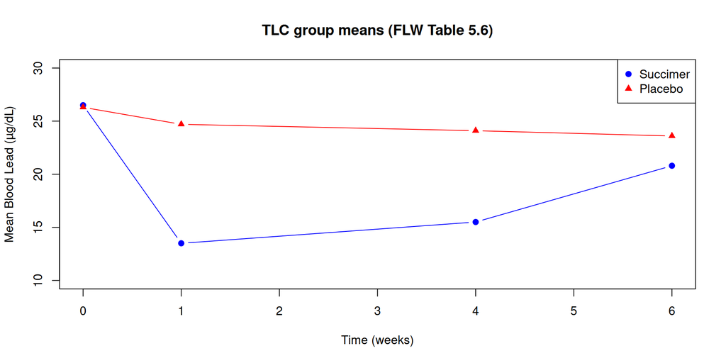

## TLC Trial Observations

| Group | Pattern |
| --- | --- |
| Succimer | Sharp decline post-baseline, then rebound |
| Placebo | Remains relatively stable over time |

## Discussion: Handling Baseline

Baseline measurements are special:

- Typically pre-randomization in trials (independent of treatment)
- May be range-restricted or differ systematically in observational studies

## Key Question: How Should Baseline Be Handled?

| Option | Description |
| --- | --- |
| Include in profile | Treat baseline as part of the response vector |
| Adjust explicitly | Use ANCOVA or contrasts |

Implications for hypothesis testing, efficiency, and power.

## Think-Pair-Share

**Tip**

**Discussion questions:**

1. In a randomized trial, why is it reasonable to treat baseline as independent of treatment?
2. How might this differ in an observational study?

**Check Your Understanding: Response Profiles Basics**

1. What type of longitudinal design is response profile analysis best suited for?
2. Why do we call them “response profiles” rather than “response curves”?
3. In the TLC trial plot, what does the sharp drop in the Succimer group at week 1 suggest?

**Answers:**

1. **Balanced longitudinal designs** where all subjects have the same planned measurement occasions (though missing data is allowed)
2. Because we estimate **discrete means at each time point** rather than assuming a continuous functional form (e.g., linear, quadratic)
3. The treatment has an immediate, strong effect on reducing blood lead levels, but the rebound suggests the effect may not be sustained

# Section 2: Hypotheses Concerning Profiles

## Three Main Hypotheses

Given $n$ occasions (time points) across $G$ groups, we test:

| Hypothesis | Description | Degrees of Freedom |
| --- | --- | --- |
| $H_{01}$ | Parallelism (no group $\times$ time interaction) | $(G-1)(n-1)$ |
| $H_{02}$ | Flatness (no time effect) | $n-1$ |
| $H_{03}$ | Same level (no group effect) | $G-1$ |

**Note**

$G$ = number of groups, $n$ = number of occasions (Ch. 5 convention). Tiny example: $G=2$ groups, $n=4$ occasions gives parallelism df $=(G-1)(n-1) = 1 \times 3 = 3$.

## Testing Order Principle

**If $H_{01}$ is rejected**, main effects ($H_{02}$, $H_{03}$) are not directly interpretable due to the presence of interaction.

**Takeaway:** Test parallelism first; only then consider main effects.

## Randomized vs. Observational Studies

| Study Type | Baseline Property | Primary Focus |
| --- | --- | --- |
| Randomized trial | Groups equal at baseline by design | $H_{01}$ (patterns of change) |
| Observational | Groups may differ at baseline | $H_{02}$, $H_{03}$ meaningful if $H_{01}$ holds |

## Visual: Parallel Profiles (No Interaction)

Two groups with **parallel** mean trajectories (constant difference over time).

```r
set.seed(1)
t <- 1:5
mu1 <- 10 + 2*t                # Group 1
mu2 <- 12 + 2*t                # Group 2 (constant +2 offset)

plot(t, mu1, type="b", pch=19, ylim=range(c(mu1, mu2)),
     xlab="Time", ylab="Mean Response", main="(a) Parallel Mean Profiles")
lines(t, mu2, type="b", pch=17)
abline(v=t, col="gray90", lty=3)
legend("topleft", legend=c("Group 1","Group 2"), pch=c(19,17), bty="n")
```

## Visual: Parallel Profiles (No Interaction)

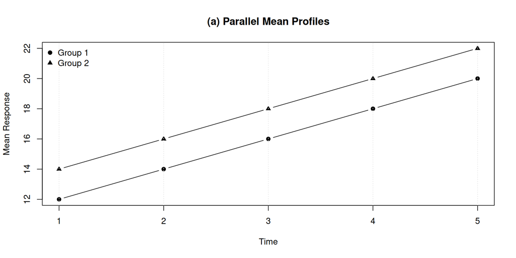

## Visual: Flat Profiles (No Time Effect)

Assuming parallelism holds, flat profiles test:

$$H_{02}: \mu_1 = \mu_2 = \cdots = \mu_n$$

```r
t <- 1:5
mu1 <- rep(15, length(t))
mu2 <- rep(20, length(t))

plot(t, mu1, type="b", pch=19, ylim=range(c(mu1, mu2)),
     xlab="Time", ylab="Mean Response", main="(b) Flat Mean Profiles (No Time Effect)")
lines(t, mu2, type="b", pch=17)
abline(v=t, col="gray90", lty=3)
legend("topleft", legend=c("Group 1","Group 2"), pch=c(19,17), bty="n")
```

## Visual: Flat Profiles (No Time Effect)

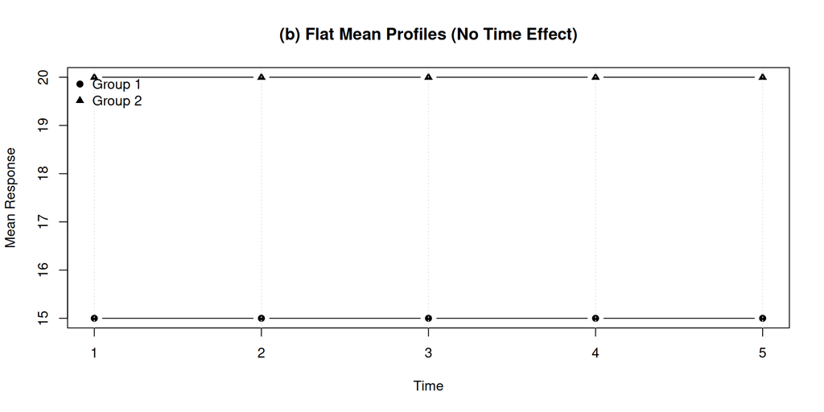

## Visual: Same Level (No Group Effect)

Assuming parallelism holds, same level tests:

$$H_{03}: \boldsymbol{\mu}^{(1)} = \boldsymbol{\mu}^{(2)} = \cdots = \boldsymbol{\mu}^{(G)}$$

```r
t <- 1:5
mu  <- 10 + 1.5*t

# The two group profiles coincide by construction (no group effect);
# add a tiny vertical jitter so both series are visible.
plot(t, mu, type="b", pch=19, ylim=range(mu),
     xlab="Time", ylab="Mean Response", main="(c) Same Level Across Groups (No Group Effect)")
lines(t, mu + 0.1, type="b", pch=17, col="gray40")
abline(v=t, col="gray90", lty=3)
legend("topleft", legend=c("Group 1","Group 2 (jittered)"), pch=c(19,17),
       col=c("black","gray40"), bty="n")
```

## Visual: Same Level (No Group Effect)

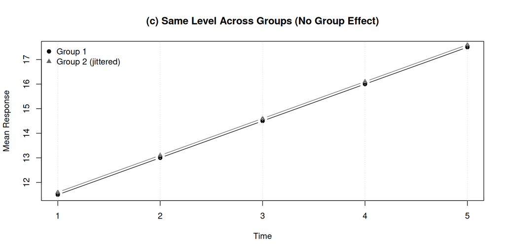

## Formal Statement: Two Groups

For Treatment ($T$) vs. Control ($C$), define:

$$\Delta_j = \mu_j^{(T)} - \mu_j^{(C)}$$

Test parallelism:

$$H_{01}: \Delta_1 = \Delta_2 = \cdots = \Delta_n \quad (n-1 \text{ df})$$

## Formal Statement: More Than Two Groups

With reference group $G$, define:

$$\Delta_j^{(g)} = \mu_j^{(g)} - \mu_j^{(G)}$$

Test parallelism:

$$H_{01}: \Delta_1^{(g)} = \cdots = \Delta_n^{(g)} \quad \forall g=1,\dots,G-1$$

with $(G-1)(n-1)$ degrees of freedom.

**Check Your Understanding: Profile Hypotheses**

1. If you have 3 groups and 5 time points, how many degrees of freedom does the parallelism test have?
2. Why should you test parallelism ($H_{01}$) before interpreting main effects?
3. If profiles are parallel, what does rejecting $H_{02}$ (flatness) tell you?

**Answers:**

1. $(G-1)(n-1) = (3-1)(5-1) = 8$ degrees of freedom
2. If there is a group $\times$ time interaction (non-parallel profiles), the “group effect” and “time effect” vary depending on which time/group you look at - main effects are not meaningful without specifying the level of the other factor
3. Rejecting flatness means there **is** a time effect - the mean response changes over time (at least one time point differs from the others)

# Section 3: General Linear Model (LM) Setup

## The General Linear Model (LM) for Response Profiles

Represent mean response profiles using the general (normal-errors) linear model, the **LM**:

$$E(\mathbf{Y}_i \mid \mathbf{X}_i) = \boldsymbol{\mu}_i = \mathbf{X}_i \boldsymbol{\beta}$$

**Notation (Ch. 5):**

| Symbol | Meaning |
| --- | --- |
| $n$ | Number of occasions (time points) |
| $N$ | Number of subjects |
| $G$ | Number of groups |
| Total parameters | $G \times n$ |

**Note**

“LM” here is the **general** linear model with normal errors. It is not the **generalized** linear model (GLM), which we reach in Ch. 11.

## Example: Two Groups, Three Occasions

Mean response profiles (column vectors):

$$\boldsymbol{\mu}^{(1)} =
\begin{pmatrix} \mu_1^{(1)} \\ \mu_2^{(1)} \\ \mu_3^{(1)} \end{pmatrix}, \quad
\boldsymbol{\mu}^{(2)} =
\begin{pmatrix} \mu_1^{(2)} \\ \mu_2^{(2)} \\ \mu_3^{(2)} \end{pmatrix}$$

Parameter vector:

$$\boldsymbol{\beta} = (\beta_1, \beta_2, \ldots, \beta_6)^\top$$

## Design Matrix Example

For a subject in **group 1** with all three occasions (cell-means coding):

$$\mathbf{X}_i =
\begin{bmatrix}
1 & 0 & 0 & 0 & 0 & 0 \\
0 & 1 & 0 & 0 & 0 & 0 \\
0 & 0 & 1 & 0 & 0 & 0
\end{bmatrix}$$

Columns 1-3 are the **group-1 cell means** (occasions 1, 2, 3); columns 4-6 are the **group-2 cell means**. So $\mathbf{X}_i \boldsymbol{\beta}$ picks out group 1 here. The map is:

$$\beta_1 = \mu_1^{(1)},\ \beta_2 = \mu_2^{(1)},\ \beta_3 = \mu_3^{(1)},\quad
\beta_4 = \mu_1^{(2)},\ \beta_5 = \mu_2^{(2)},\ \beta_6 = \mu_3^{(2)}$$

## Expressing Hypotheses via Contrasts

Hypothesis of no group $\times$ time interaction:

$$H_{01}: \mathbf{L}\boldsymbol{\beta} = \mathbf{0}$$

Each row of $\mathbf{L}$ encodes one $\Delta_j - \Delta_{j+1} = 0$ comparison, where $\Delta_j = \mu_j^{(2)} - \mu_j^{(1)}$. With $\boldsymbol{\beta} = (\mu_1^{(1)},\mu_2^{(1)},\mu_3^{(1)},\mu_1^{(2)},\mu_2^{(2)},\mu_3^{(2)})^\top$, one row testing $\Delta_1 = \Delta_2$ is:

Setting all $n-1$ such rows to $\mathbf{0}$ forces $\Delta_1 = \cdots = \Delta_n$ (parallelism).

**Testing methods:** Wald or likelihood ratio tests

## Visual: Observed Means

```r
time <- 1:3
mu_group1 <- c(10, 14, 18)
mu_group2 <- c(11, 16, 21)  # slightly different slope

plot(time, mu_group1, type="b", pch=19, col="blue", ylim=c(10,22),
     xlab="Time", ylab="Mean Response", main="Observed Means")
lines(time, mu_group2, type="b", pch=17, col="red")
legend("topleft", legend=c("Group 1","Group 2"),
       col=c("blue","red"), pch=c(19,17), bty="n")
```

## Visual: Observed Means

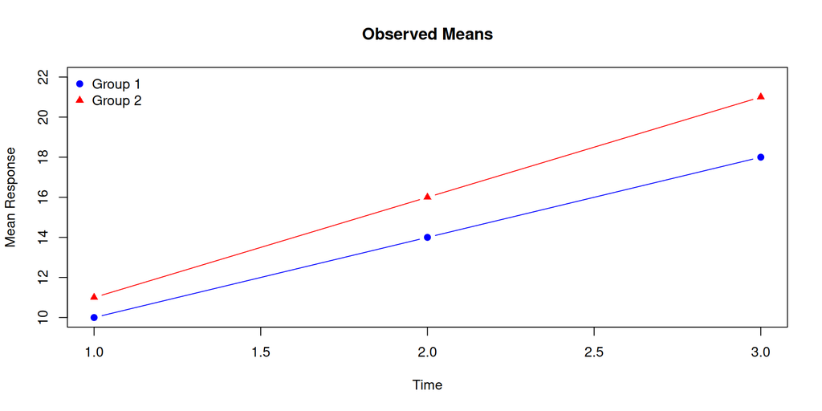

## Visual: Fitted Full Model

Full model: each group $\times$ time cell estimated freely.

```r
plot(time, mu_group1, type="b", pch=19, col="blue", ylim=c(10,22),
     xlab="Time", ylab="Mean Response", main="Fitted Means (Full Model)")
lines(time, mu_group2, type="b", pch=17, col="red")
legend("topleft", legend=c("Group 1","Group 2"),
       col=c("blue","red"), pch=c(19,17), bty="n")
```

## Visual: Fitted Full Model

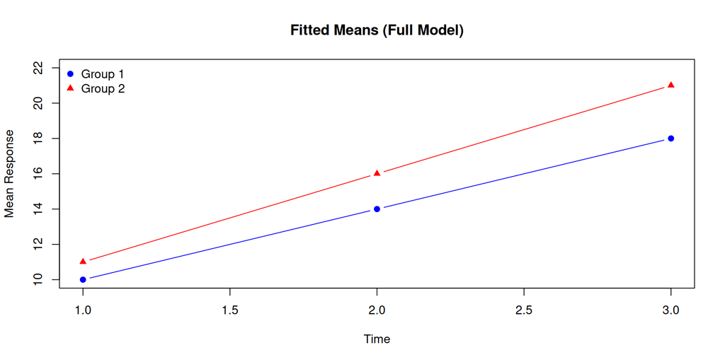